# KNN classification

## NIRANJAN POUDEL (Niranjan111@hotmail.com)

```python
import numpy as np
import pandas as pd
import matplotlib.pyplot as plt
import seaborn as sns
sns.set
```

```
<function seaborn.rcmod.set(context='notebook', style='darkgrid', palette='deep', font='sans-serif', font_scale=1, color_codes=True, rc=None)>
```

### Previously we have saved the train and test set as the pickle file, lets extract those file.

```python
train = pd.read_pickle(r"C:\Users\Niranjan.p\Desktop\Home work and assignments\machine learning\Kaggle\titanic\new_train.pkl")
test = pd.read_pickle(r"C:\Users\Niranjan.p\Desktop\Home work and assignments\machine learning\Kaggle\titanic\new_test.pkl")
```

```python
train.head(5)
```

|  | Survived | Age | SibSp | Parch | Fare | Pclass_2 | Pclass_3 | Sex_male | Cabin_No_info | Embarked_Q | Embarked_S | Title_Miss | Title_Mr | Title_Mrs | Title_Other | Tick_CA | Tick_No_info | Tick_Other | Tick_PC |
| --- | --- | --- | --- | --- | --- | --- | --- | --- | --- | --- | --- | --- | --- | --- | --- | --- | --- | --- | --- |
| 0 | 0 | 2.2 | 1 | 0 | 0.072500 | 0 | 1 | 1 | 1 | 0 | 1 | 0 | 1 | 0 | 0 | 0 | 0 | 0 | 0 |
| 1 | 1 | 3.8 | 1 | 0 | 0.712833 | 0 | 0 | 0 | 0 | 0 | 0 | 0 | 0 | 1 | 0 | 0 | 0 | 0 | 1 |
| 2 | 1 | 2.6 | 0 | 0 | 0.079250 | 0 | 1 | 0 | 1 | 0 | 1 | 1 | 0 | 0 | 0 | 0 | 0 | 1 | 0 |
| 3 | 1 | 3.5 | 1 | 0 | 0.531000 | 0 | 0 | 0 | 0 | 0 | 1 | 0 | 0 | 1 | 0 | 0 | 1 | 0 | 0 |
| 4 | 0 | 3.5 | 0 | 0 | 0.080500 | 0 | 1 | 1 | 1 | 0 | 1 | 0 | 1 | 0 | 0 | 0 | 1 | 0 | 0 |

```python
train.info()
```

```
<class 'pandas.core.frame.DataFrame'>
RangeIndex: 891 entries, 0 to 890
Data columns (total 19 columns):
 #   Column         Non-Null Count  Dtype
---  ------         --------------  -----
 0   Survived       891 non-null    int64
 1   Age            891 non-null    float64
 2   SibSp          891 non-null    int64
 3   Parch          891 non-null    int64
 4   Fare           891 non-null    float64
 5   Pclass_2       891 non-null    uint8
 6   Pclass_3       891 non-null    uint8
 7   Sex_male       891 non-null    uint8
 8   Cabin_No_info  891 non-null    uint8
 9   Embarked_Q     891 non-null    uint8
 10  Embarked_S     891 non-null    uint8
 11  Title_Miss     891 non-null    uint8
 12  Title_Mr       891 non-null    uint8
 13  Title_Mrs      891 non-null    uint8
 14  Title_Other    891 non-null    uint8
 15  Tick_CA        891 non-null    uint8
 16  Tick_No_info   891 non-null    uint8
 17  Tick_Other     891 non-null    uint8
 18  Tick_PC        891 non-null    uint8
dtypes: float64(2), int64(3), uint8(14)
memory usage: 47.1 KB
```

It looks like saving as a pickle is soulution to saving the data_type as the dummies are as unit

### We already did simple scaling previously dividing Age by 10 and Fare by 100, and from my simple cross-check i am getting better results, so leaving it as it is!!

### First splitting the data as required.

```python
y_train = train['Survived']
X_train = train.drop('Survived',axis=1)
X_test=test.drop('PassengerId',axis=1)
```

### KNN Classification with Sklearn

```python
from sklearn.neighbors import KNeighborsClassifier
```

```python
### Fitting KNN classifier to th Training set, first simply using the number of neighbors as 5
KNN = KNeighborsClassifier(n_neighbors=5)
KNN.fit(X_train,y_train)
```

```
KNeighborsClassifier(algorithm='auto', leaf_size=30, metric='minkowski',
                     metric_params=None, n_jobs=None, n_neighbors=5, p=2,
                     weights='uniform')
```

### Lets do the cross validation (K=5 and K=10) for the model fitted with 5 neighbors initially

```python
from sklearn.model_selection import cross_val_score
```

```python
accuracy = cross_val_score(estimator = KNN, X=X_train,y=y_train, cv=5,scoring='accuracy')
```

```python
accuracy
```

```
array([0.77653631, 0.78651685, 0.80337079, 0.79775281, 0.85955056])
```

```python
round(accuracy.mean(),3)
```

```
0.805
```

### From 10 cross validations

```python
accuracy = cross_val_score(estimator = KNN, X=X_train,y=y_train, cv=10,scoring='accuracy')
```

```python
round(accuracy.mean(),3)
```

```
0.808
```

### Lets further move to choosing the value of K from cross validation, both (K=5 and 10) of train set

```python
CV_error_rate =[]
k=50

for i in range(1,k):
    KNN_i = KNeighborsClassifier(n_neighbors=i)
    KNN_i.fit(X_train, y_train)
    MAE_i = -1*cross_val_score(estimator = KNN_i, X=X_train , y= y_train,cv=5, scoring='neg_mean_absolute_error')
    CV_error_rate.append(np.mean(MAE_i)) ## I think this is correct matemathically as you stated in class because we get 5 MAE and take the mean
                                         ## mean to get 1 number

K_value = pd.DataFrame({'CV_error_rates': CV_error_rate},index=range(1,k))
```

```python
K_value
```

|  | CV_error_rates |
| --- | --- |
| 1 | 0.235654 |
| 2 | 0.223326 |
| 3 | 0.207589 |
| 4 | 0.193020 |
| 5 | 0.195255 |
| 6 | 0.181803 |
| 7 | 0.182926 |
| 8 | 0.182914 |
| 9 | 0.185180 |
| 10 | 0.185199 |
| 11 | 0.185186 |
| 12 | 0.182939 |
| 13 | 0.186303 |
| 14 | 0.185174 |
| 15 | 0.185174 |
| 16 | 0.179568 |
| 17 | 0.185180 |
| 18 | 0.173938 |
| 19 | 0.177308 |
| 20 | 0.187402 |
| 21 | 0.182926 |
| 22 | 0.184056 |
| 23 | 0.186291 |
| 24 | 0.184044 |
| 25 | 0.186291 |
| 26 | 0.180679 |
| 27 | 0.181803 |
| 28 | 0.180679 |
| 29 | 0.181803 |
| 30 | 0.180673 |
| 31 | 0.182926 |
| 32 | 0.182926 |
| 33 | 0.185174 |
| 34 | 0.184056 |
| 35 | 0.182933 |
| 36 | 0.180692 |
| 37 | 0.184056 |
| 38 | 0.182945 |
| 39 | 0.185186 |
| 40 | 0.185186 |
| 41 | 0.185186 |
| 42 | 0.185180 |
| 43 | 0.185180 |
| 44 | 0.186310 |
| 45 | 0.186297 |
| 46 | 0.187433 |
| 47 | 0.187433 |
| 48 | 0.188557 |
| 49 | 0.184069 |

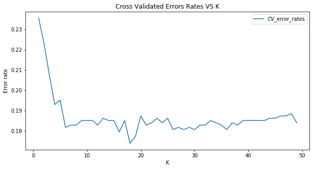

```python
plt.figure(figsize=(10,5))
sns.lineplot(data=K_value)
plt.title('Cross Validated Errors Rates VS K')
plt.xlabel('K')
plt.ylabel('Error rate')
plt.show()
```

From 5 cross-validation the number of K-neighbors is 18

### Next we do 10 cross validation

```python
CV_error_rate =[]
k=50

for i in range(1,k):
    KNN_i = KNeighborsClassifier(n_neighbors=i)
    KNN_i.fit(X_train, y_train)
    MAE_i = -1*cross_val_score(estimator = KNN_i, X=X_train , y= y_train,cv=10, scoring='neg_mean_absolute_error')
    CV_error_rate.append(np.mean(MAE_i))

K_value = pd.DataFrame({'CV_error_rates': CV_error_rate},index=range(1,k))
```

```python
K_value
```

|  | CV_error_rates |
| --- | --- |
| 1 | 0.230025 |
| 2 | 0.209850 |
| 3 | 0.203084 |
| 4 | 0.188514 |
| 5 | 0.191860 |
| 6 | 0.182884 |
| 7 | 0.181773 |
| 8 | 0.176192 |
| 9 | 0.186280 |
| 10 | 0.184057 |
| 11 | 0.187416 |
| 12 | 0.171685 |
| 13 | 0.180674 |
| 14 | 0.179526 |
| 15 | 0.179538 |
| 16 | 0.175056 |
| 17 | 0.178427 |
| 18 | 0.173920 |
| 19 | 0.177291 |
| 20 | 0.180674 |
| 21 | 0.179538 |
| 22 | 0.179538 |
| 23 | 0.185144 |
| 24 | 0.181785 |
| 25 | 0.181785 |
| 26 | 0.179526 |
| 27 | 0.185131 |
| 28 | 0.181748 |
| 29 | 0.180662 |
| 30 | 0.179538 |
| 31 | 0.181773 |
| 32 | 0.181773 |
| 33 | 0.179538 |
| 34 | 0.180649 |
| 35 | 0.185144 |
| 36 | 0.182909 |
| 37 | 0.185144 |
| 38 | 0.187391 |
| 39 | 0.187391 |
| 40 | 0.186267 |
| 41 | 0.187391 |
| 42 | 0.187391 |
| 43 | 0.187416 |
| 44 | 0.184032 |
| 45 | 0.181810 |
| 46 | 0.184057 |
| 47 | 0.186292 |
| 48 | 0.187416 |
| 49 | 0.185169 |

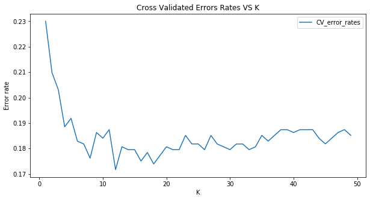

```python
plt.figure(figsize=(10,5))
sns.lineplot(data=K_value)
plt.title('Cross Validated Errors Rates VS K')
plt.xlabel('K')
plt.ylabel('Error rate')
plt.show()
```

### From 5-cross validation the k-value is 18 wheras from the 10 cross-validation the number is 12 but mean square error is less for K=12 from 10 cross validation, so we choose 12

### The following thing we have already done above in the for loop but doing again for neighbor 12-only

```python
KNN_updated = KNeighborsClassifier(n_neighbors=12)
KNN_updated.fit(X_train,y_train)
```

```
KNeighborsClassifier(algorithm='auto', leaf_size=30, metric='minkowski',
                     metric_params=None, n_jobs=None, n_neighbors=12, p=2,
                     weights='uniform')
```

```python
accuracy = cross_val_score(estimator = KNN_updated, X=X_train,y=y_train, cv=5,scoring='accuracy')
error_rate = -1*cross_val_score(estimator = KNN_updated, X = X_train, y = y_train, cv = 5 , scoring="neg_mean_absolute_error" )
```

```python
round(accuracy.mean(),3)
```

```
0.817
```

```python
round(error_rate.mean(),3)
```

```
0.183
```

### From 10-cross validation

```python
accuracy = cross_val_score(estimator = KNN_updated, X=X_train,y=y_train, cv=10,scoring='accuracy')
error_rate = -1*cross_val_score(estimator = KNN_updated, X = X_train, y = y_train, cv = 10 , scoring="neg_mean_absolute_error" )
```

```python
round(accuracy.mean(),3)
```

```
0.828
```

```python
round(error_rate.mean(),3)
```

```
0.172
```

### Next let us predict for the test set

```python
y_pred_test = KNN_updated.predict(X_test)
```

```python
y_pred_test
```

```
array([0, 0, 0, 0, 0, 0, 1, 0, 1, 0, 0, 0, 1, 0, 1, 1, 0, 0, 0, 1, 0, 0,
       1, 0, 1, 0, 1, 0, 0, 0, 0, 0, 1, 0, 1, 0, 0, 0, 0, 1, 0, 0, 0, 1,
       1, 0, 0, 0, 1, 1, 0, 0, 0, 1, 0, 0, 0, 0, 0, 1, 0, 0, 0, 1, 1, 1,
       1, 0, 0, 0, 1, 0, 0, 0, 1, 0, 0, 1, 0, 1, 1, 0, 0, 0, 0, 0, 1, 0,
       0, 1, 0, 0, 1, 0, 0, 0, 1, 0, 0, 0, 1, 0, 0, 0, 0, 0, 0, 0, 0, 0,
       0, 1, 1, 1, 1, 0, 0, 1, 1, 1, 1, 0, 1, 0, 0, 0, 0, 1, 0, 0, 0, 0,
       0, 0, 0, 0, 0, 0, 0, 0, 0, 1, 0, 0, 0, 0, 0, 0, 0, 0, 1, 0, 0, 1,
       0, 0, 1, 0, 0, 1, 1, 1, 1, 0, 0, 0, 0, 0, 1, 0, 0, 0, 0, 0, 0, 1,
       1, 0, 1, 1, 0, 1, 1, 0, 1, 0, 1, 0, 0, 0, 0, 0, 1, 0, 1, 0, 1, 0,
       0, 1, 1, 1, 1, 1, 0, 0, 1, 0, 1, 0, 0, 0, 0, 1, 0, 0, 1, 0, 1, 0,
       1, 0, 1, 0, 1, 0, 0, 1, 0, 0, 0, 1, 0, 0, 0, 0, 0, 0, 1, 1, 1, 1,
       1, 0, 1, 0, 1, 0, 1, 1, 1, 0, 1, 0, 0, 0, 0, 0, 1, 0, 0, 0, 1, 1,
       0, 0, 0, 0, 0, 0, 0, 0, 1, 1, 0, 1, 0, 0, 0, 0, 0, 1, 1, 1, 1, 0,
       0, 0, 0, 0, 0, 1, 0, 0, 0, 0, 1, 0, 0, 0, 0, 0, 0, 0, 1, 1, 0, 1,
       0, 0, 0, 0, 0, 1, 1, 1, 0, 0, 0, 0, 0, 0, 0, 0, 1, 0, 1, 0, 0, 0,
       1, 0, 0, 0, 0, 0, 0, 0, 0, 1, 0, 0, 0, 1, 1, 0, 0, 1, 0, 1, 1, 0,
       0, 0, 1, 0, 1, 0, 0, 0, 0, 1, 1, 0, 1, 0, 0, 0, 1, 0, 0, 1, 0, 0,
       1, 1, 0, 0, 0, 0, 0, 0, 1, 0, 0, 1, 0, 0, 0, 0, 0, 1, 1, 0, 0, 1,
       0, 1, 0, 0, 1, 0, 1, 0, 0, 0, 0, 0, 1, 1, 1, 1, 0, 0, 1, 0, 0, 1],
      dtype=int64)
```

```python
submission=pd.DataFrame({'PassengerId':test['PassengerId'],'Survived':y_pred_test})
```

```python
submission.to_csv(r'C:\Users\Niranjan.p\Desktop\Home work and assignments\machine learning\submission_knn_test.csv',index=False)
```

## Before this submission the rank in kaggle was 4826, now the submission from KNN is not better than logistic regression, so the rank is 4826 from logistic regression submission, unfortunate ..